# Introdução às Séries Temporais Financeiras

Conceitos e Aplicações em R

Jailson Rodrigues

1/26/2021

### Outline

- Introdução
- Séries financeiras e econômicas
  - Fatos Estilizados
- Aplicação
  - Estudo de caso
    - Grafico da série de preços
    - Correlograma
    - Retornos e log-retornos
    - Correlograma dos retornos
    - Retornos de quadráticos
    - Teste para efeitos ARCH
    - Ajuste do modelo GARCH(1,1)
  - Avaliação
  - Interpretação
- Conclusão

# Introdução

“*All models are wrong, but some are usefull*”

-Geroge P. Box

Parsimony principle: *Since all models are wrong the scientist cannot obtain a “correct” one by excessive elaboration.*

#### Modelos GARCH

GARCH: Generalized Auto-Regresive Conditional Heteroscedasticity ou Modelo Auto-Regresivo com Hereroscedasticidade Condicional Generalizado

Quando a suposição de *resíduos homoscedásticos* (Variância não é constante) não é verificada os modelos convencionais como *ARMA* e *ARIMA* não são adequados, pois não foram criados para modelar esse tipo de carcterística.

Para isso, utilizamos uma classe de modelos capaz de comportar a *heteroscedasticidade*, muito presente nas séries temporais financeiras e econômicas.

A expressão para o modelo GARCH(q, p) é dada a seguir:

$$r_t = \sigma_t \eta_t$$

$$\sigma_t^2 = \omega+ \sum_{i=1}^q \alpha_{t-i}r_t^2+\sum_{j=1}^p \beta_{t-i}\sigma_{t-j}^2$$
Em que:

$\eta_t \sim N(0, 1)$ (NORMAL-GARCH)

$r^2$: retornos observados elevados ao quadrado

$\sigma_{t}$: Variância condicional no tempo

$\alpha$: Parâmetro que explica a taxa com a qual os choques do periodo anterior explicam os choques no periodo atual

$\beta$ Explica a persistencia dos choques na volatilidade, ou o por quanto tempo persistem influenciando a variabilidade da série temporal.

As aplicações do modelo GARCH estão principalmente no ramo de Gestão de Risco, já que as empresas gostariam de saber que tipo de exposição seus ativos irão enfrentar no futuro.

## Fatos Estilizados

Fatos estilizados são ***evidências visuais empiricas** que podemos observar no comportamento de alguns tipos de séries temporais tais quais econômicas e financeiras.

- Clusters de volatilidade
- Tendência evidente
- Variabilidade que muda ao longo do tempo (não constante)
- Choques causam efeitos persistentes na série
- Deslocamento ou Drift

# Aplicação

A série temporal do preço da ação da Aamazon é mostrada no gráfico a seguir:

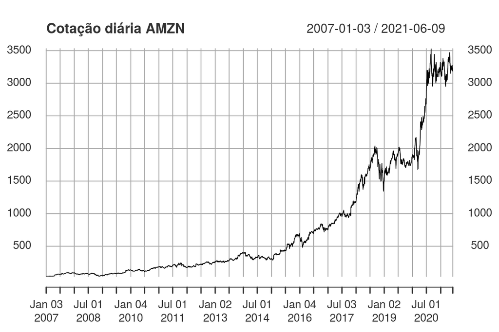

```r
plot(AMZN$AMZN.Close,lwd=0.8,main= 'Cotação diária AMZN')
```

Perceba que diversos clusters de volatilidade estão presentes na série, principalmente entre os anos de 2018 e 2020.

Modelos Para avaliarmos melhor isso, podemos plotar o gráfico dos retornos quadráticos.

### Log-retornos

```r
#retornoS
rt = na.omit(diff(log(Pt), lag=1))
##rt <- log(1+retorno)
```

Utilizamos log-retorno devido a suas propriedades estatísticas, como estacionariedade e ergodicidade.

Podemos descrever alguns fatos estiliazados que são encontrados na maioria das séries de retornos:

- Estacionariedade
- Fraca dependência linear e não linear
- Caudas pesadas na distribuição e excesso de curtose
- Comportamento heterocedástico condicional

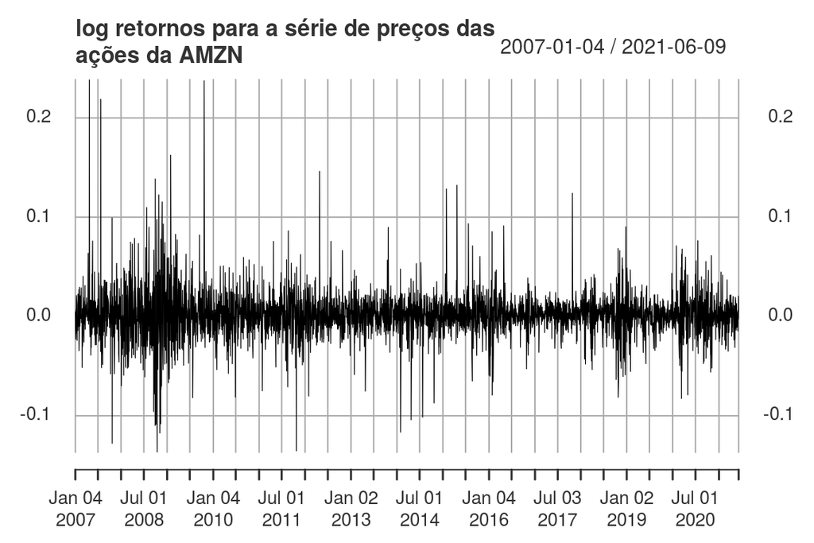

```r
par(mfrow = c(1,1))
plot(rt, lwd = 0.6,main='log retornos para a série de preços das \nações da AMZN')
```

Perceba que o padrão visto acima caracteriza o fato estilizado cluster de volatilidade. Períodos com grandes variações tendem a ser seguidos por períodos com grandes variações.

*Cont, Rama. Empirical properties of asset returns: stylized facts and statistical issues. (2001): 223-236)*

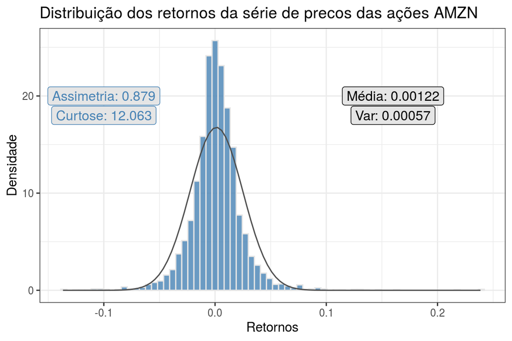

Uma característica bastante recorrente em séries financeiras é a presença de excesso de curtose, provocando caudas pesadas, como pode ser visto no histogama acima.

```r
ret_portifolio = data.frame((data.frame(rt) %>% rownames),
                            rt,
                            rt^2,
                            abs(rt))

colnames(ret_portifolio) = c('Data','Retorno', 'Retorno_sq','Retorno_abs')
ret_portifolio %>% gather(Tiporetorno, Retono, -Data) -> ret_portifolio
ret_portifolio$Data <- as.Date(ret_portifolio$Data)
```

Estatísticas descritivas para o log-retorno, log-retorno absoluto e quadrático

```r
ret_portifolio %>% group_by(Tiporetorno) %>% summarise(Min =min(Retono),
                                                       mu = mean(Retono),
                                                       DP = sd(Retono)^2,
                                                       Max = max(Retono)) %>%   kbl() %>%kable_material(c("striped", "hover"))
```

| Tiporetorno | Min | mu | DP | Max |
| --- | --- | --- | --- | --- |
| Retorno | -0.1367589 | 0.0012222 | 0.0005657 | 0.2386209 |
| Retorno_abs | 0.0000000 | 0.0158228 | 0.0003168 | 0.2386209 |
| Retorno_sq | 0.0000000 | 0.0005670 | 0.0000046 | 0.0569400 |

Retornos absolutos são robustos na presença de outliers. Retornos quadráticos capturam menos essa variabilidade, porém são mais fáceis de tratar matemáticamente, por isso geralmente são preferíveis.

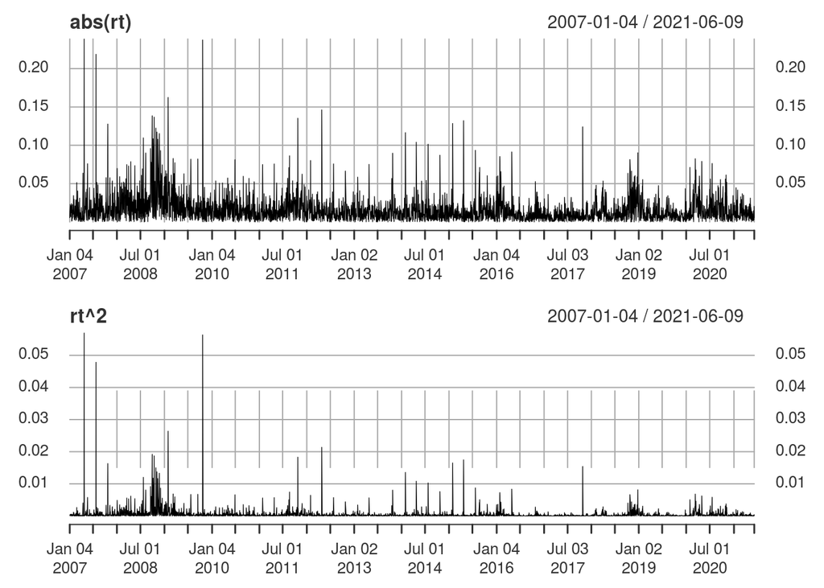

```r
par(mfrow = c(2,1))
plot(abs(rt), lwd =0.6)
plot(rt^2, lwd =0.6)
```

O correlograma dos retornos ordinários mostram evidencias de nao haver correlação linear, mas os retornos de segunda ordemnos dizem que existe forte correlação não linear nos dados.

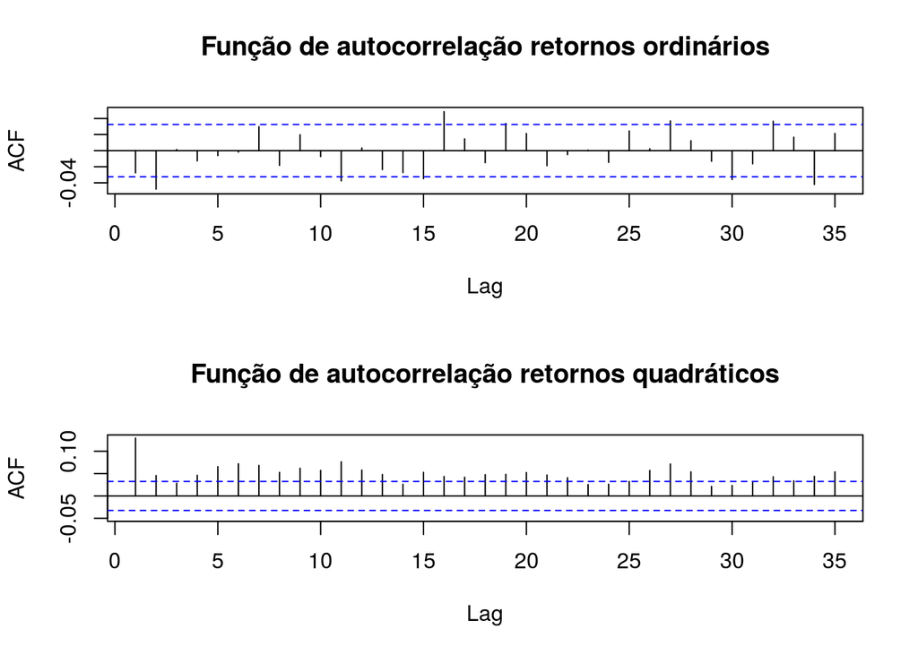

```r
par(mfrow=c(2,1))
Acf((na.omit((rt))), main = 'Função de autocorrelação retornos ordinários')
Acf((na.omit((rt^2))), main = 'Função de autocorrelação retornos quadráticos')
```

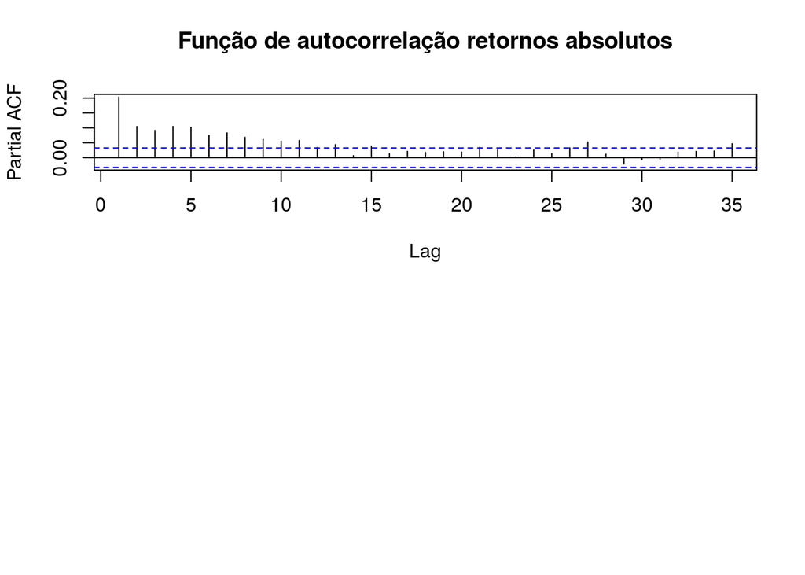

```r
stats::pacf((na.omit(abs(rt))), main = 'Função de autocorrelação retornos absolutos')
```

### Teste de efeitos ARCH

- Algoritmo para testar efeitos ARCH:
  1. Especificar o modelo AR
  2. Estimar via Mínimos Quadrados Ordinários ou MLE não ha solucao analítica, mas saiba que $\hat{\sigma}^2 = f(r_t^2)$
  3. Obeter os resíduos do modelo
  4. Calcular os resíduos quadráticos
  5. Performar o teste dos Multiplicadores de Lagrange

$H_0:$ *Resíduos são Homoscedásticos*

$H_1:$ *Presença de efeitos ARCH*

Se os coeficientes ARCH forem significativos -> presença de heteroscedasticidade caso contrário, não temos indícios de heteroscedasticidade e nao haverá necessidade de utilizar modelos GARCH

```r
modelo_ar <- arima(Pt$AMZN.Close,order = c(5,2,1))
summary(modelo_ar)
```

```
##
## Call:
## arima(x = Pt$AMZN.Close, order = c(5, 2, 1))
##
## Coefficients:
##           ar1      ar2      ar3     ar4      ar5      ma1
##       -0.0544  -0.0022  -0.0846  0.0194  -0.0069  -0.9986
## s.e.   0.0166   0.0167   0.0166  0.0167   0.0167   0.0014
##
## sigma^2 estimated as 520.3:  log likelihood = -16514.65,  aic = 33043.3
##
## Training set error measures:
##                     ME     RMSE     MAE        MPE     MAPE      MASE
## Training set 0.4058461 22.80385 10.6314 0.01402699 1.585082 0.9971086
##                       ACF1
## Training set -0.0006561457
```

```r
arch.test(modelo_ar,output = TRUE)
```

```
## ARCH heteroscedasticity test for residuals
## alternative: heteroscedastic
##
## Portmanteau-Q test:
##      order   PQ p.value
## [1,]     4 1291       0
## [2,]     8 2132       0
## [3,]    12 3107       0
## [4,]    16 3877       0
## [5,]    20 4577       0
## [6,]    24 5351       0
## Lagrange-Multiplier test:
##      order   LM p.value
## [1,]     4 2769       0
## [2,]     8 1260       0
## [3,]    12  751       0
## [4,]    16  507       0
## [5,]    20  387       0
## [6,]    24  308       0
```

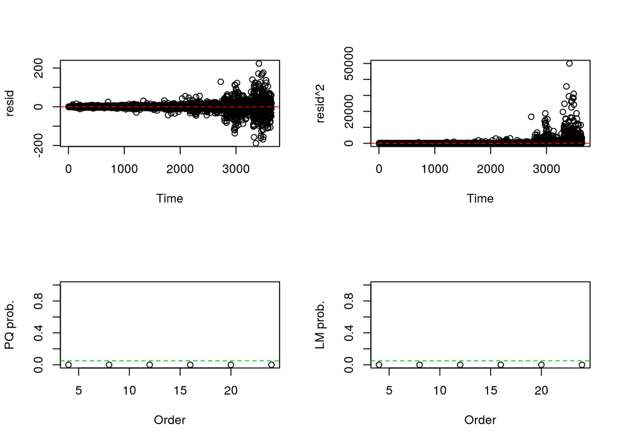

Os testes acima nos dizem que temos indícios para crer na existência de efeitos ARCH.

O teste de Engle, baseias-se no fato de que sob a hipótese nula que os resíduos são seguem um Ruído Branco. Caso sejam heteroscedásticos, os resíduos quadráticos serão autocorrelacionados.

### Estimando a volatilidade dos preços das ações da Amazon

#### Especificando um modelo ARMA-GARCH(1, 1)

```r
garch11 <- ugarchspec(
    variance.model = list(model = c("sGARCH","gjrGARCH","eGARCH","fGARCH",
                                    "apARCH")[1],
                          garchOrder = c(1, 1)),
    mean.model = list(armaOrder = c(1, 1), include.mean = TRUE),
    distribution.model = c("norm", "snorm", "std", "sstd", "ged", "sged", "nig",
                           "ghyp",
                           "jsu")[1])
```

```r
ajuste11 <- ugarchfit(garch11,rt)
summary(ajuste11)
```

```
##    Length     Class      Mode
##         1 uGARCHfit        S4
```

#### Volatilidade estimada

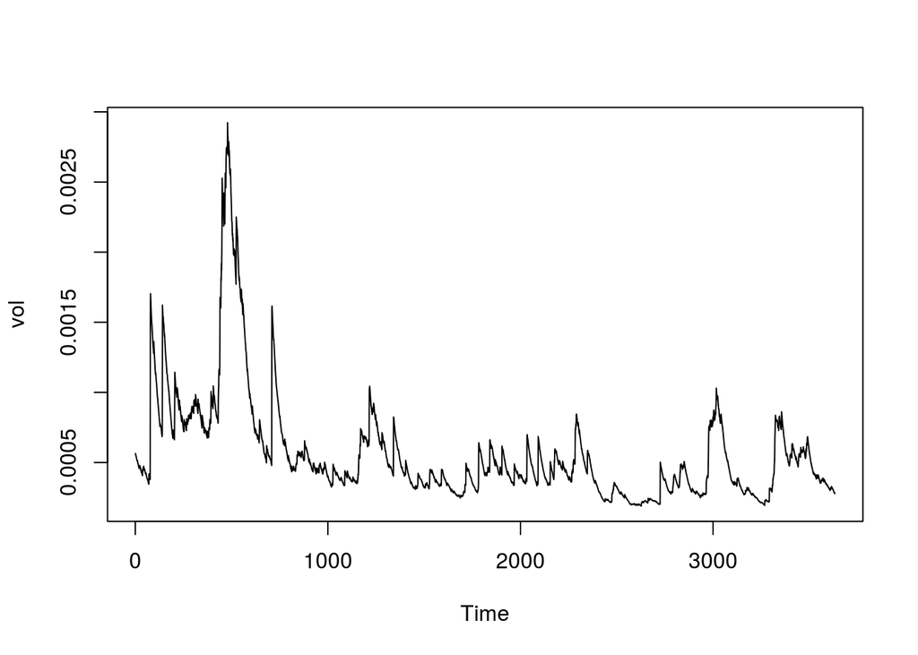

```r
vol <- ts(ajuste11@fit$sigma^2)
plot.ts(vol)
```

#### Diagnóstico do modelo

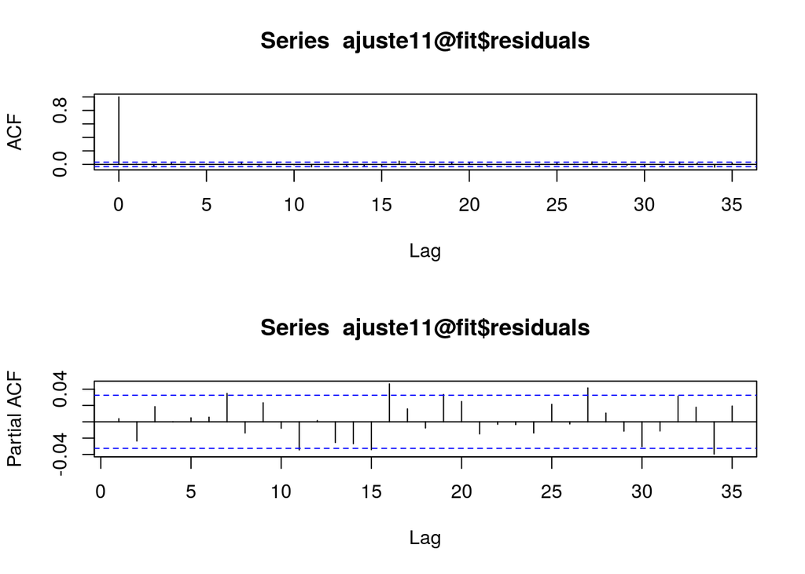

```r
par(mfrow=c(2,1))
acf(ajuste11@fit$residuals)
pacf(ajuste11@fit$residuals)
```

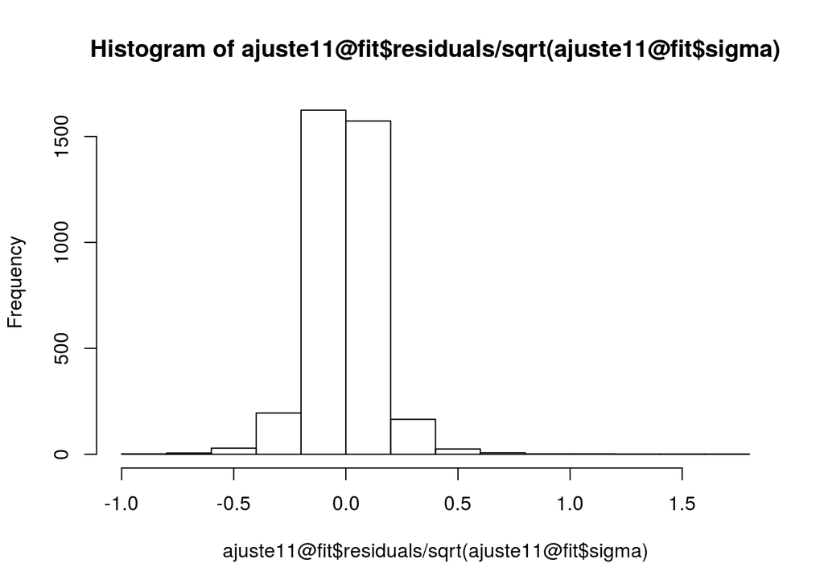

```r
hist(ajuste11@fit$residuals/sqrt(ajuste11@fit$sigma))
```

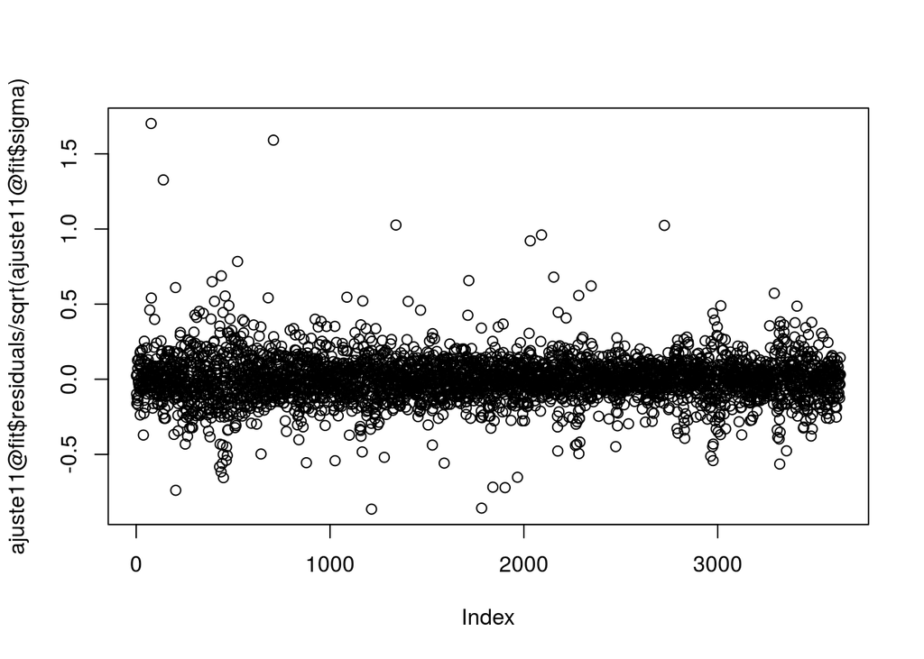

```r
plot(ajuste11@fit$residuals/sqrt(ajuste11@fit$sigma))
```

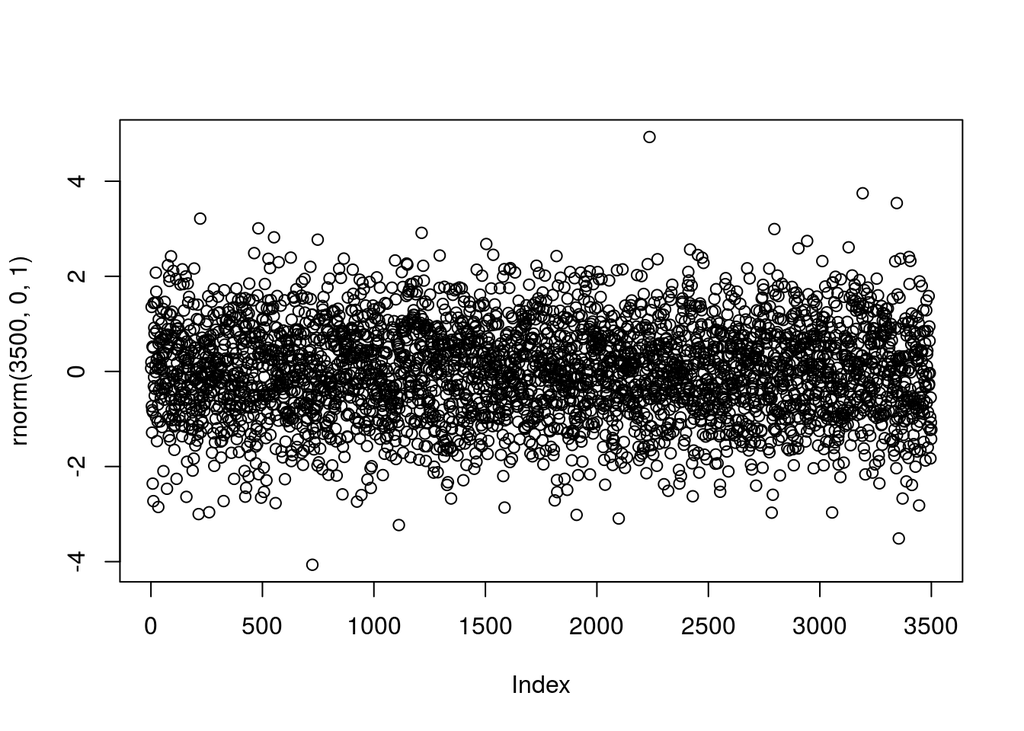

```r
plot(rnorm(3500,0,1))
```